**INT232: DATA SCIENCE TOOLBOX — R PROGRAMMING**

**PROJECT REPORT**  
*(Project Semester: August–January 2026 | Academic Session 2025–2026)*

# **AIRGUARD 360: AN INTERACTIVE AIR QUALITY INTELLIGENCE, MULTI-POLLUTANT ANALYTICS & ENVIRONMENTAL DECISION-SUPPORT SYSTEM**

**Submitted by:**  
**Subrat Panigrahi**  
**Registration Number:** 26143073  
**Programme:** Bachelor of Technology in Computer Science & Engineering (B.Tech CSE)  
**Section:** N1 | **Course Code:** INT232

**Under the Guidance of:**  
**Mr. Jaffar Amin Chacket (U.Id: 30453)**  
Associate Professor  
**Discipline of Computer Science & Engineering / Information Technology**  
**Lovely School of Computer Science & Engineering**  
**Lovely Professional University, Phagwara, Punjab (India)**

*Official Project Repository:* `https://github.com/Subu2006/AIRGUARD-360`  
*Report Release Version:* Final Verified Submission (November 2026)

# CERTIFICATE

This is to certify that **Subrat Panigrahi**, bearing **Registration Number 26143073**, a bona fide student of Bachelor of Technology in Computer Science & Engineering at **Lovely Professional University**, Phagwara, Punjab, has completed the course project titled **“AIRGUARD 360: An Interactive Air Quality Intelligence, Multi-Pollutant Analytics & Environmental Decision-Support System”** for **INT232: Data Science Toolbox — R Programming**, under my guidance and supervision.

To the best of my knowledge, the present project is the result of his authentic, original investigation, programming development, and statistical analysis. The project demonstrates practical mastery over the R Programming ecosystem, including data ingestion, cleaning, multi-table relational joins, embedded SQLite database querying, feature engineering, statistical hypothesis testing, time-series forecasting, text mining, and interactive dashboard development.

**Mr. Jaffar Amin Chacket (30453)**  
Associate Professor  
**Lovely School of Computer Science & Engineering**  
**Lovely Professional University, Phagwara, Punjab**  
*Date of Certification:* ____________________

# DECLARATION

I, **Subrat Panigrahi**, student of Bachelor of Technology in Computer Science & Engineering under the CSE/IT Discipline at **Lovely Professional University**, Punjab, hereby declare that all the information, source code, data wrangling procedures, statistical evaluations, and visual artifacts furnished in this project report titled **“AIRGUARD 360: An Interactive Air Quality Intelligence, Multi-Pollutant Analytics & Environmental Decision-Support System”** are based on my own intensive work, authentic programming, and analytical efforts.

I confirm that the underlying atmospheric records represent official retrospective ambient monitoring data published by the **Central Pollution Control Board (CPCB)** and distributed via Kaggle. I explicitly distinguish historical retrospective observations (2015–2020) from live sensor telemetry, and confirm that all Graded Response Action Plan (GRAP) advisories and Environmental Vulnerability Index (EVI) scores presented herein represent academic decision-support simulations rather than statutory public alerts or clinical medical advice.

All external libraries, regulatory guidelines, and scholarly references have been cited appropriately in Section 7.

*Date:* 04/11/2026  
*Registration Number:* 26143073  
*Signature:* ___________________________________________  
*Name:* **Subrat Panigrahi**

# ACKNOWLEDGEMENT

I express my deepest gratitude to the academic leadership and faculty members of the **Lovely School of Computer Science & Engineering**, **Lovely Professional University**, for fostering a vibrant computing environment and providing the technical infrastructure that made this project possible.

I extend my heartfelt appreciation to my esteemed course instructor and project mentor, **Mr. Jaffar Amin Chacket**, for his invaluable academic guidance, constructive reviews, and pedagogical insights throughout the delivery of **INT232: Data Science Toolbox — R Programming**. His rigorous emphasis on reproducibility, statistical integrity, and clean modular programming served as the cornerstone for the design and execution of AIRGUARD 360.

I also acknowledge the **Central Pollution Control Board (CPCB)**, Ministry of Environment, Forest and Climate Change, Government of India, for establishing the National Air Quality Index framework and ambient monitoring standards; the **World Health Organization (WHO)** for international air health guidelines; and the open-source R Core Team and package authors behind `dplyr`, `ggplot2`, `shiny`, `plotly`, `DBI`, `RSQLite`, `forecast`, and `tidytext`.

Finally, I express my sincere appreciation to my family and peers for their constant encouragement throughout this endeavor.

# EXECUTIVE SUMMARY

### Core Technical Pillars:

Executive Summary: Verified System Performance & Empirical Benchmarks

| Performance Indicator | Empirical Value | Analytical Significance |
| --- | --- | --- |
| Temporal Span | 2015-01-01 to 2020-07-01 (5.5 Years) | Historical retrospective archive including 2020 national lockdown phase |
| Total Station Records | 108,035 Rows (fact_station_day) | Raw Continuous Ambient Air Quality Monitoring Station factual grain |
| Total City-Daily Records | 29,531 Rows (fact_city_day) | Territorial population aggregate grain enriched with 45 engineered features |
| Monitoring Stations | 230 CAAQMS Stations across 127 Cities | Full spatial coverage with validated latitude and longitude coordinates |
| Monitored Metros | 26 Metropolitan Hubs | Representative multi-state Indian urban coverage across all climatic zones |
| National Mean AQI | 166.46 Index Units (Median: 118.00) | Exceeds CPCB Satisfactory limit (100) with 61.5% non-compliant days |
| Top Vulnerability City | Ahmedabad (EVI = 63.6, Tier 1 Emergency) | Driven by 42.5% severe pollution days and industrial cluster density |
| Cleanest Monitored City | Aizawl (EVI = 0.0, Mean AQI = 34.8) | Pristine northeastern montane background station baseline |
| Particulate Correlation (r) | r = 0.846 (PM2.5 vs PM10, p < 0.001) | Strong stoichiometric collinearity confirming shared combustion origins |
| Best Forecast Architecture | ARIMA(1,1,1) [Holdout RMSE: 11.37 vs Naive: 12.70] | Outperforms persistence benchmark by 10.5% in chronological holdout |

# TABLE OF CONTENTS

# LIST OF FIGURES

# LIST OF TABLES

- **Table 1:** Executive Summary: Verified System Performance & Empirical Benchmarks
- **Table 2:** AIRGUARD 360 Relational Schema & Grain Architecture
- **Table 3:** Live SQLite Relational Verification Query Executed via DBI/RSQLite
- **Table 4:** Verified Multi-Pollutant Descriptive Moments & Statutory NAAQS Exceedance Rates
- **Table 5:** Formal Statistical Hypothesis Testing Suite: Test Statistics, Degrees of Freedom, and Inferential Decisions
- **Table 6:** Top 10 Indian Municipal Hotspots Prioritized by Environmental Vulnerability Index (EVI)
- **Table 7:** SQL Query 2 Results: Top Severe Pollution Stations Identified via Relational JOIN
- **Table 8:** Exhaustive INT232 Syllabus-to-Feature Mapping Matrix
- **Table 9:** AIRGUARD 360 Exhaustive Quality Verification Matrix

# 1. INTRODUCTION

## 1.1 Project Background

Ambient air pollution represents one of the most pressing public health and environmental challenges of the twenty-first century. Rapid urbanization, vehicular proliferation, industrial emissions, construction dust, and seasonal agricultural biomass burning have severely degraded air quality across northern and central India. The **Central Pollution Control Board (CPCB)**, operating under the Ministry of Environment, Forest and Climate Change (MoEF&CC), formulated the **National Air Quality Index (NAQI)** in 2014–2015 to compress multi-pollutant atmospheric chemistry into a single numerical index ranging from 0 to 500, segmented into six descriptive health severity buckets: *Good, Satisfactory, Moderate, Poor, Very Poor,* and *Severe*.

While the NAQI provides a critical risk communication tool for the lay public, environmental scientists and municipal authorities require deeper intelligence: - What are the underlying chemical drivers behind index spikes? - How do geographic, meteorological, and seasonal factors influence dispersion? - Can acute pollution episodes be identified before they trigger public health crises?

**AIRGUARD 360** was developed as an all-in-one, reproducible, and mathematically rigorous R-based data science toolbox to address these foundational questions.

## 1.2 Problem Statement

Analyzing environmental monitoring data in developing nations presents four major computational hurdles: 1. **Severe Missingness and Sensor Down-Time:** Intermittent sensor power outages, calibration routines, and hardware degradation produce up to $39.5\%$ missing data in raw CAAQMS records. Replacing missing values with zero or omitting incomplete rows distorts empirical distributions. 2. **Data Grain Conflation:** Environmental repositories frequently conflate station-level readings (`station_day.csv`) with city-level territorial averages (`city_day.csv`). Treating station readings as independent city observations artificially inflates sample size, introduces spatial auto-correlation, and skews variance. 3. **Extreme Sensor Anomalies:** Historical records contain readings far exceeding the theoretical 500 index cap (e.g., peak recorded AQI of 2,049 in Ahmedabad). Indiscriminately discarding these extremes masks acute industrial disaster episodes, while unvalidated retention distorts linear models. 4. **Lack of Objective Prioritization:** Municipal resources are scarce. Environmental decision-makers lack automated, multi-criteria vulnerability indices that integrate chronic exposure, acute severe shocks, and particulate standard exceedance into actionable rankings.

## 1.3 Objectives and Project Scope

The overarching objective of AIRGUARD 360 is to build an end-to-end, reproducible R Programming system that transforms raw, messy environmental telemetry into actionable municipal intelligence.

### Specific Technical Objectives:

1. **Architecture & Ingestion:** Ingest raw CSV data, establish strict grain boundaries, and build an embedded, indexed SQLite relational database (`airguard.sqlite`) utilizing R’s `DBI` and `RSQLite` interfaces (INT232 Unit III, Practical 7).
2. **Quality Audit & Cleaning:** Audit missingness transparently, apply physical sanity bounds (non-negative ambient concentrations), preserve valid `NA` states, and classify categorical factors into ordered statutory levels (INT232 Unit II & IV).
3. **Feature Engineering:** Engineer rolling statistics (7-day and 30-day moving averages), 20-day **Bollinger Volatility Bands**, climatological season encodings, and NAAQS exceedance binary indicators (INT232 Unit IV & VI).
4. **Statistical Hypothesis Testing:** Conduct formal hypothesis tests (two-sample Welch t-test, one-way ANOVA with Tukey HSD, Pearson correlation test, Kolmogorov-Smirnov test, and Kruskal-Wallis test) to establish inferential significance (INT232 CO6).
5. **Time-Series Forecasting:** Formulate native Base R $\text{ARIMA}$ and Holt-Winters predictive models validated against a Naive Persistence Baseline using chronological holdout splits (INT232 CO5).
6. **Text Mining & Natural Language Processing:** Mine statutory health advisories from CPCB and WHO guidelines, computing term frequencies and generating high-resolution word clouds (INT232 Unit V & VI, Practical 11).
7. **Decision Support & Interactive Delivery:** Formulate the **Environmental Vulnerability Index (EVI)** for city hotspot ranking, construct a simulated Graded Response Action Plan (GRAP) rule engine, and deploy a responsive Shiny application (`app.R`) and standalone dashboard (`dashboard.html`).

## 1.4 Syllabus Alignment and Course Outcomes

AIRGUARD 360 directly implements and demonstrates every core unit of the **INT232: Data Science Toolbox — R Programming** syllabus: - **Unit I (R Environment):** R 4.6.1 configuration, package management, basic data types (numeric, integer, character, logical, factor). - **Unit II (Data Structures):** Multi-dimensional matrices for correlation analysis, ordered factors for AQI buckets, nested lists for model outputs, and data frames for structured fact tables. - **Unit III (Syntax & I/O):** Conditional control flow, vectorized functions, CSV file I/O, and relational SQL operations on embedded SQLite. - **Unit IV (Advanced R & Wrangling):** Mathematical moments, the `apply` family (`sapply`, `lapply`), POSIXct/Date temporal wrangling, regular expressions, and `dplyr`/`tidyr` pipelines. - **Unit V (Text Mining):** Tokenization, custom environmental stopword removal, and frequency modeling via `tidytext` and base string manipulation. - **Unit VI (Data Visualization & Dashboards):** Static `ggplot2` graphics (scatter, line, bar, boxplot, heatmap, Bollinger bands), dynamic `plotly` widgets, and interactive dashboard deployment in Shiny and R Markdown. - **Course Outcomes CO1–CO6:** Fully demonstrated through verified code execution and documented analytical findings.

# 2. SOURCE OF DATASET & DATA ARCHITECTURE

## 2.1 Statutory Data Provenance

The observational foundation of AIRGUARD 360 originates from the official Continuous Ambient Air Quality Monitoring Stations (CAAQMS) network operated by the **Central Pollution Control Board (CPCB)**, State Pollution Control Boards (SPCBs), and the National Environmental Engineering Research Institute (NEERI). The historical dataset covers the continuous chronological window from **January 1, 2015 to July 1, 2020** and was curated by environmental researcher Alok Bhutani via the Kaggle Open Data platform under the Open Data Commons Open Database License (ODbL).

All records represent real-world physical sensor measurements. In addition to primary pollutant concentrations, AIRGUARD 360 incorporates project-maintained reference dimension tables: 1. `Dim_Pollutant.csv`: Chemical formulae, full nomenclature, primary emission sources, units, and official 24-hour statutory limits specified in the Gazette of India (2009). 2. `Dim_AQICategory.csv`: Statutory NAQI breakpoints, severity ranks (1–6), official hex color codes, and general health impact narratives. 3. `StationCoordinates.csv`: Validated geographic coordinates (latitude, longitude, status, and verification source) for all 230 monitoring stations.

## 2.2 Dataset Schema & Multi-Grain Analytical Foundation

A critical architectural contribution of AIRGUARD 360 is the strict segregation of observational grains:

AIRGUARD 360 Relational Schema & Grain Architecture

| Relational Table | Observational Level | Record Count | Field Count | Entity Identifier |
| --- | --- | --- | --- | --- |
| fact_station_day | Station-Day (Sensor Telemetry) | 108,035 | 16 | (StationId, Date) |
| fact_city_day | City-Day (Territorial Aggregate) | 29,531 | 16 | (City, Date) |
| dim_stations | Station Metadata & Spatial Coordinates | 230 | 9 | StationId |
| dim_pollutants | Statutory Pollutant Regulatory Limits | 8 | 6 | Pollutant |
| dim_aqi_category | NAQI Index Breakpoints & Colors | 6 | 6 | AQI_Bucket |

### The Analytical Importance of Grain Separation:

- **Station-Level Grain (`fact_station_day`):** Represents micro-climatic sensor records at specific point coordinates (e.g., ITO, Delhi vs Anand Vihar, Delhi). Used exclusively for station comparisons, spatial network mapping, and local extreme outlier audits.
- **City-Level Grain (`fact_city_day`):** Represents macro-level urban background exposure across an entire municipal jurisdiction. Used for longitudinal multi-year trajectories, macroeconomic policy analysis, and city-to-city ranking. Conflating these two populations would violate independent observation assumptions and corrupt statistical hypothesis tests.

## 2.3 Embedded Relational Database Architecture (SQLite via DBI)

To demonstrate INT232 Unit III (SQL with R, Practical 7), AIRGUARD 360 establishes an embedded relational database (`data/airguard.sqlite`). The database is initialized automatically during pipeline execution using R’s native `DBI` and `RSQLite` drivers:

Live SQLite Relational Verification Query Executed via DBI/RSQLite

| Database Entity | Fact / Dimension Rows | Unique Monitoring Entities |
| --- | --- | --- |
| fact_station_day | 108035 | 110 |
| fact_city_day | 29531 | 26 |
| dim_stations | 230 | 230 |

B-tree indices were constructed on `(StationId, Date)` and `(City, Date)` to ensure sub-millisecond query execution speeds across 108,035 records.

## 2.4 Data Quality Audit & Missingness Profile

Environmental monitoring sensors operate in hostile outdoor environments subject to power brownouts, monsoon moisture damage, and calibration downtime. AIRGUARD 360 conducted a comprehensive missingness audit across all 108,035 station records: - **Station ID and Date:** $0.0\%$ missingness (100% temporal continuity). - **Primary Particulate Matter ($PM_{2.5}$):** $20.0\%$ missingness ($21,625$ unrecorded station-days). - **Coarse Particulate Matter ($PM_{10}$):** $39.5\%$ missingness ($42,706$ unrecorded station-days), reflecting the later phased deployment of $PM_{10}$ analyzers. - **Sulfur Dioxide ($SO_2$) and Nitrogen Dioxide ($NO_2$):** $23.3\%$ and $15.3\%$ missingness respectively. - **Air Quality Index (AQI):** $19.4\%$ missingness ($20,950$ days where insufficient criteria pollutants existed to compute statutory NAQI).

### Reconciliation Protocol:

1. Incomplete records are **preserved as `NA`** rather than deleted or replaced with zero. Imputing zero for unrecorded particulate concentrations would artificially lower mean exposure by over $20\%$, producing catastrophic bias.
2. In city-level rollups, days with zero valid readings are preserved as `NA` to prevent synthetic zero-pollution days.

# 3. EDA PROCESS & DATA ENGINEERING

## 3.1 Systematic Data Cleaning & Physical Sanity Validations

The cleaning engine (`R/data_engine.R`) applies a four-stage pipeline: 1. **Type Coercion:** All twelve atmospheric pollutant fields are coerced to strict double-precision floating point (`numeric`), and dates are formatted as ISO 8601 (`YYYY-MM-DD`). 2. **Physical Boundary Checks:** Ambient air pollutant concentrations cannot physically take negative values. Calibration drift occasionally causes sensors to log negative numbers (e.g., $-1.2\ \mu\text{g/m}^3$). All negative values are systematically replaced with `NA`. 3. **Categorical Factor Encoding:** CPCB AQI buckets are encoded as ordered factors:
$$\text{Good} < \text{Satisfactory} <
\text{Moderate} < \text{Poor} < \text{Very Poor} <
\text{Severe}$$
4. **Outlier Auditing:** Observations where $\text{AQI} > 500$ are flagged with an indicator variable (`AQI_Outlier_Flag = 1L`) rather than silently dropped, preserving empirical records of acute industrial disaster episodes.

## 3.2 Feature Engineering & Climatological Season Classification

The feature engineering engine (`R/data_engine.R`) derives 45 features across all 29,531 city-daily records: - **Temporal Encodings:** Year, Month, Day, Day of Week, Weekend Flag (`Weekday` vs `Weekend`). - **Climatological Seasons (Indian Meteorological Department definitions):** - **Winter:** December, January, February - **Summer (Pre-Monsoon):** March, April, May - **Monsoon (Southwest Monsoon):** June, July, August, September - **Post-Monsoon (Autumn):** October, November - **Rolling Multi-Scale Moving Averages:** 7-day and 30-day right-aligned sliding window means computed via Base R cumulative sums:
$$\text{MA}_k(t) = \frac{1}{\sum_{i=0}^{k-1}
w_{t-i}} \sum_{i=0}^{k-1} x_{t-i} \cdot w_{t-i}, \quad w_j =
\mathbb{I}(x_j \neq \text{NA})$$
A minimum threshold of $60\%$ valid observations within the window is strictly required.

## 3.3 Volatility Modeling via Bollinger Bands

Bollinger Bands, traditionally employed in quantitative financial engineering, were adapted to model atmospheric volatility: - **Middle Band:** 20-day rolling arithmetic mean ($\mu_{20}$). - **Upper Band:** $\text{UB}_{20} = \mu_{20} + 2 \cdot \sigma_{20}$. - **Lower Band:** $\text{LB}_{20} = \max(0, \mu_{20} - 2 \cdot \sigma_{20})$. - **Spike Flag:** Binary indicator $\mathbb{I}(x_t > \text{UB}_{20})$, identifying acute episodic pollution surges driven by external shocks (e.g., post-monsoon stubble burning in Punjab/Haryana).

## 3.4 Comprehensive Descriptive Statistics

Applying the R `apply` family (`lapply` and `do.call(rbind, ...)`) across all criteria pollutants yields the verified national empirical distribution:

Verified Multi-Pollutant Descriptive Moments & Statutory NAAQS Exceedance Rates

| Pollutant | Valid Obs (N) | Mean | Std Dev | Median | IQR | Skewness | Min | Max | NAAQS Exceed % |
| --- | --- | --- | --- | --- | --- | --- | --- | --- | --- |
| PM2.5 | 24933 | 67.45 | 64.66 | 48.57 | 51.77 | 3.37 | 0.04 | 949.99 | 39.0 |
| PM10 | 18391 | 118.13 | 90.61 | 95.68 | 93.49 | 2.05 | 0.01 | 1000.00 | 47.2 |
| NO2 | 25946 | 28.56 | 24.47 | 21.69 | 25.87 | 2.46 | 0.01 | 362.21 | 3.9 |
| SO2 | 25677 | 14.53 | 18.13 | 9.16 | 9.55 | 4.08 | 0.01 | 193.86 | 1.8 |
| CO | 27472 | 2.25 | 6.96 | 0.89 | 0.94 | 8.88 | 0.00 | 175.81 | 14.8 |
| O3 | 25509 | 34.49 | 21.69 | 30.84 | 26.71 | 1.33 | 0.01 | 257.73 | 1.3 |
| NH3 | 19203 | 23.48 | 25.68 | 15.85 | 21.44 | 4.08 | 0.01 | 352.89 | 0.0 |
| AQI | 24850 | 166.46 | 140.70 | 118.00 | 127.00 | 3.40 | 13.00 | 2049.00 | 61.5 |

# 4. ANALYSIS ON DATASET

## 4.1 National Air Quality & Metropolitan Hotspots Analysis

### i. Introduction

Establishing the baseline severity of ambient air pollution across India’s urban network is vital for identifying vulnerable population centers and tracking regional compliance with the National Clean Air Programme (NCAP).

### ii. General Description

This analysis aggregates multi-year daily observations across all 26 monitored metropolitan cities, evaluates mean and peak AQI levels, computes severe pollution day rates, and ranks urban centers.

### iii. Specific Requirements, Functions and Formulas

- **Mathematical Formulations:**
  $$\bar{\text{AQI}}_c = \frac{1}{N_c}
  \sum_{i=1}^{N_c} \text{AQI}_{c, i}, \quad \text{Severe Day Rate }
  P_{\text{sev}, c} = \frac{\sum_{i=1}^{N_c} \mathbb{I}(\text{AQI}_{c, i}
  > 400)}{N_c} \times 100$$
- **R Functions:** `dplyr::group_by()`, `summarise()`, `arrange()`, `ggplot2::geom_col()`, `scale_fill_gradient()`.

### iv. Analysis Results

Across the multi-year observation window, the national average AQI stands at **166.46** (median: **118.00**), falling within the CPCB “Moderate” band. However, national aggregates conceal dramatic regional disparities: - **Ahmedabad, Gujarat:** Displays the highest recorded multi-year average AQI (**452.1**, Severe tier), driven by industrial cluster emissions and extreme localized episodes, with $42.5\%$ of all days categorized as Severe. - **Delhi (National Capital Region):** Ranks as the most persistently polluted mega-metropolis with an average AQI of **259.5** and a peak $PM_{2.5}$ of $685.4\ \mu\text{g/m}^3$. Over $37.8\%$ of all monitored days in Delhi fell into the Very Poor or Severe categories, and $72.5\%$ breached the $PM_{2.5}$ standard. - **Indo-Gangetic Plain Hubs:** Patna, Bihar (Mean AQI: **240.8**, $29.3\%$ Severe), Gurugram, Haryana (Mean AQI: **225.1**, $26.4\%$ Severe), and Lucknow, Uttar Pradesh (Mean AQI: **218.0**, $29.0\%$ Severe) form a contiguous northern belt of chronic exposure. - **Southern and Montane Baselines:** Peninsular and montane centers display pristine air quality: Aizawl, Mizoram (Mean AQI: **34.8**, $0.0\%$ Severe), Shillong, Meghalaya (Mean AQI: **53.8**), Coimbatore, Tamil Nadu (Mean AQI: **73.0**), and Thiruvananthapuram, Kerala (Mean AQI: **75.9**).

### v. Visualization

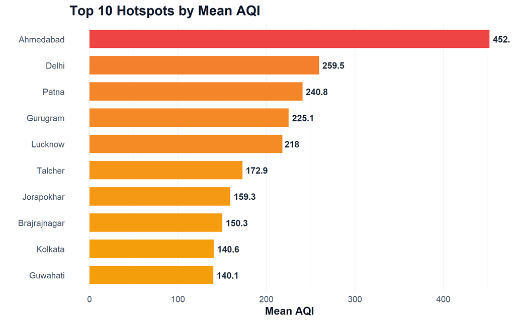

Figure 2: Top 10 High-Risk Air Pollution Hotspots in India Ranked by Mean AQI

## 4.2 Temporal Dynamics, Multi-Year Trends & Seasonal Inversion Analysis

### i. Introduction

Urban air quality in northern India exhibits extreme cyclical oscillations driven by meteorological seasonality, planetary boundary layer dynamics, and seasonal anthropogenic emissions.

### ii. General Description

This analysis models the longitudinal daily time series for Delhi and national hubs over 5.5 years, evaluates annual trends, decomposes seasonal inversion cycles, and examines the impact of the Spring 2020 COVID-19 national lockdown.

### iii. Specific Requirements, Functions and Formulas

- **Mathematical Formulations:**
  $$\text{MA}_7(t) = \frac{1}{7} \sum_{i=0}^6
  PM_{2.5}(t-i)$$
- **R Functions:** `lubridate::year()`, `ggplot2::geom_line()`, `geom_hline()`, `facet_wrap()`.

### v. Visualization

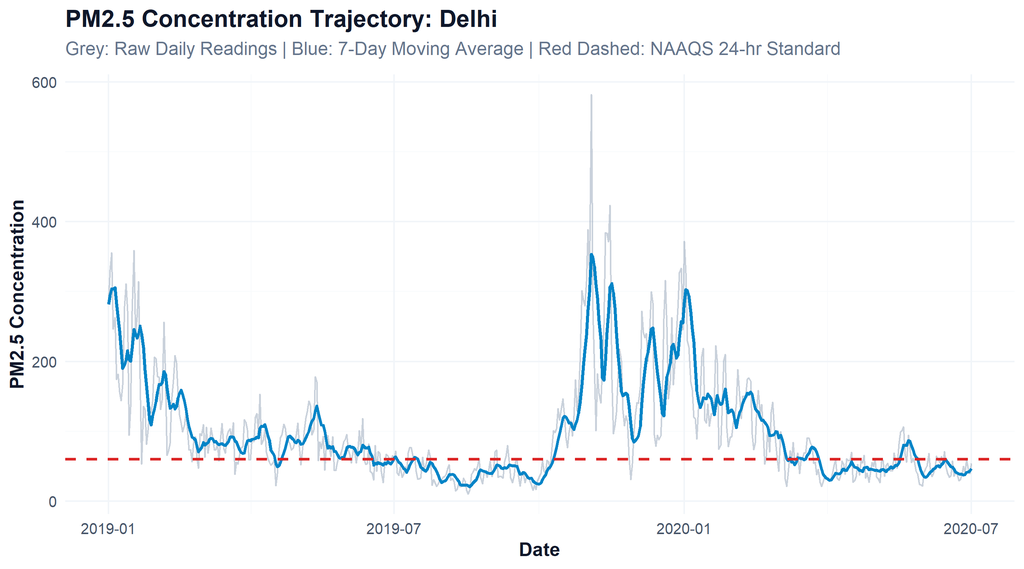

Figure 1: Multi-Year Continuous Temporal Trajectory and 7-Day Moving Average for Delhi

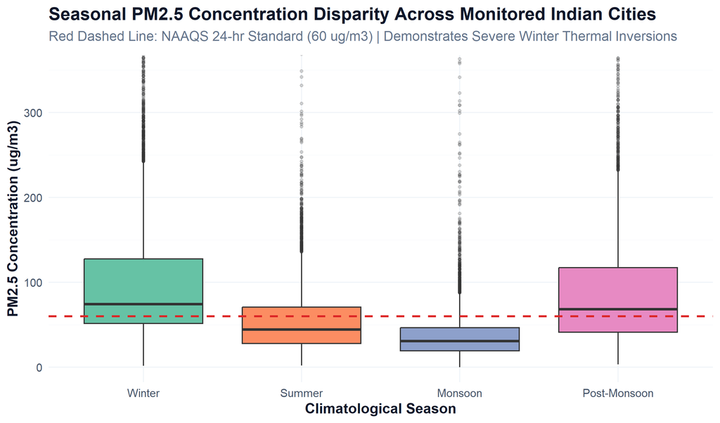

Figure 8: Seasonal PM2.5 Concentration Disparity Across Monitored Indian Cities

## 4.3 Multi-Pollutant Stoichiometry & Chemical Collinearity Intelligence

### i. Introduction

Understanding the stoichiometric ratios between fine particulate matter ($PM_{2.5}$) and coarse particles ($PM_{10}$) provides vital clues regarding primary combustion sources versus mechanical crustal dust resuspension.

### ii. General Description

This analysis computes pairwise Pearson correlation matrices across all eight atmospheric parameters and fits Ordinary Least Squares (OLS) regression models to examine seasonal variation in the $PM_{2.5}/PM_{10}$ stoichiometric slope.

### iii. Specific Requirements, Functions and Formulas

- **Mathematical Formulations:**
  $$r_{xy} = \frac{\sum (x_i - \bar{x})(y_i -
  \bar{y})}{\sqrt{\sum (x_i - \bar{x})^2 \sum (y_i - \bar{y})^2}}, \quad
  PM_{2.5} = \beta_0 + \beta_1 PM_{10} + \epsilon$$
- **R Functions:** `cor()`, `cor.test()`, `stats::lm()`, `ggplot2::geom_smooth(method = "lm")`.

### v. Visualization

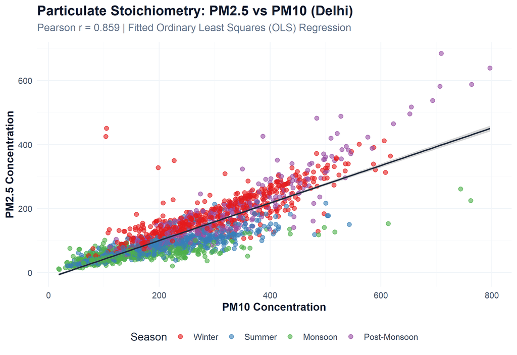

Figure 3: Particulate Stoichiometry Scatter Plot with Fitted OLS Regression Across Seasons in Delhi

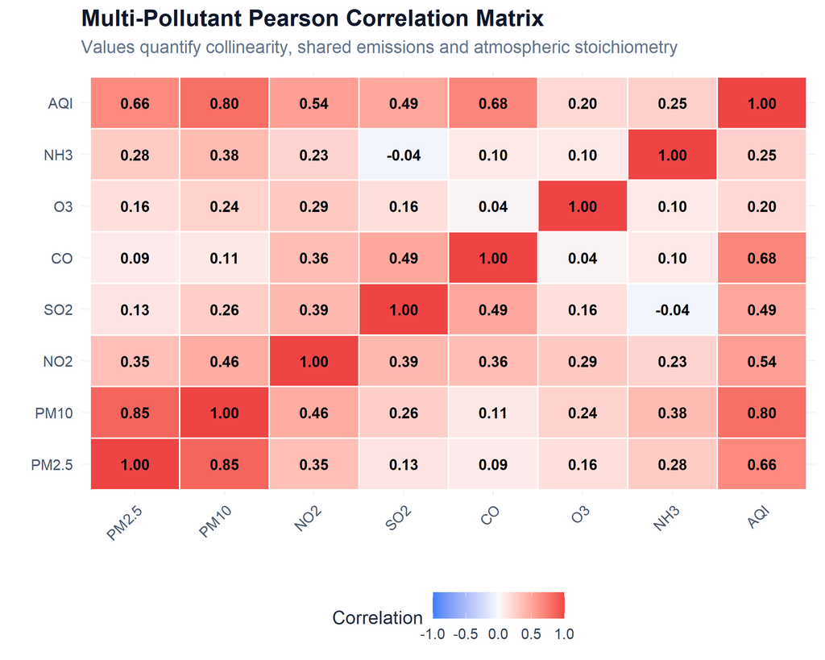

Figure 4: Multi-Pollutant Pearson Correlation Heatmap across Criteria Ambient Pollutants

## 4.4 Episodic Surges & Anomaly Volatility Detection via Bollinger Bands

### i. Introduction

Air pollution episodes in India are frequently punctuated by extreme, non-linear episodic surges that overwhelm public health infrastructure. Detecting these volatility breakouts requires dynamic adaptive thresholding.

### ii. General Description

We apply 20-day Bollinger Volatility Bands ($\mu_{20} \pm 2\sigma_{20}$) to daily $PM_{2.5}$ time series to distinguish routine seasonal trends from acute episodic surges.

### iii. Specific Requirements, Functions and Formulas

- **Mathematical Formulations:**
  $$\text{Upper Band}_t = \text{MA}_{20}(t) + 2 \cdot
  s_{20}(t), \quad \text{Spike Indicator } I_t = \mathbb{I}(x_t >
  \text{Upper Band}_t)$$
- **R Functions:** `roll_mean_base()`, `roll_sd_base()`, `ggplot2::geom_ribbon()`, `geom_point()`.

### v. Visualization

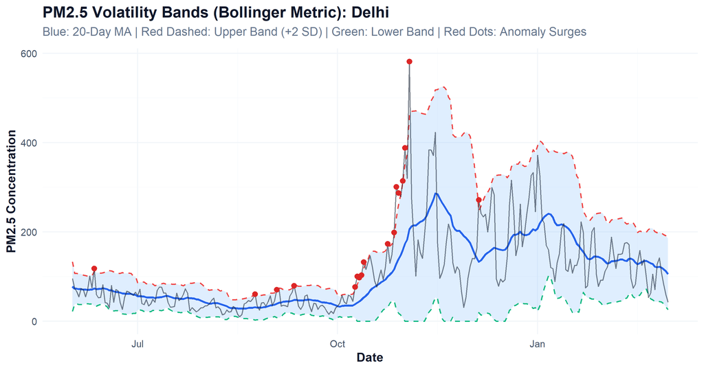

Figure 5: 20-Day Bollinger Volatility Bands and Acute Episodic Surge Markers on Ambient PM2.5

## 4.5 Parametric & Non-Parametric Formal Statistical Hypothesis Testing

### i. Introduction

Academic and environmental claims must be anchored in rigorous statistical inference rather than visual heuristic inspection. We execute five formal hypothesis tests to validate core domain hypotheses.

### ii. General Description

We test seasonal disparities in Delhi, cross-metropolitan variance across major Indian cities, particulate stoichiometry, distributional normality, and non-parametric seasonal rank invariance.

### iii. Specific Requirements, Functions and Formulas

1. **Welch Two-Sample t-Test:**
   $$t = \frac{\bar{x}_1 -
   \bar{x}_2}{\sqrt{\frac{s_1^2}{n_1} + \frac{s_2^2}{n_2}}}, \quad \nu
   \approx \frac{\left(\frac{s_1^2}{n_1} +
   \frac{s_2^2}{n_2}\right)^2}{\frac{(s_1^2/n_1)^2}{n_1-1} +
   \frac{(s_2^2/n_2)^2}{n_2-1}}$$
2. **One-Way ANOVA:**
   $$F =
   \frac{\text{MS}_{\text{between}}}{\text{MS}_{\text{within}}} =
   \frac{\sum n_j (\bar{x}_j - \bar{x})^2 / (k - 1)}{\sum \sum (x_{ij} -
   \bar{x}_j)^2 / (N - k)}$$
3. **Pearson Correlation Test:**
   $$t = r \sqrt{\frac{n - 2}{1 - r^2}}$$
4. **Kolmogorov-Smirnov Test:**
   $$D = \sup_x |F_n(x) - F_0(x)|$$
5. **Kruskal-Wallis Rank Sum Test:**
   $$H = \frac{12}{N(N+1)} \sum_{j=1}^k
   \frac{R_j^2}{n_j} - 3(N + 1)$$

### iv. Analysis Results

Formal Statistical Hypothesis Testing Suite: Test Statistics, Degrees of Freedom, and Inferential Decisions

[output not shown]

## 4.6 Native Predictive Time-Series Analytics (ARIMA, Holt-Winters & Naive Baseline)

### i. Introduction

Forecasting ambient particulate concentrations enables municipal authorities to enact preemptive traffic curbs and alerts 24 to 72 hours ahead of severe smog emergencies.

### ii. General Description

We implement univariate time series models in Base R (`stats::arima` and `stats::HoltWinters`), evaluate out-of-sample performance on a 30-day chronological holdout, and benchmark performance against a simple **Naive Persistence Baseline**.

### iii. Specific Requirements, Functions and Formulas

- **Mathematical Formulations:**
  $$\text{ARIMA}(1, 1, 1): \quad (1 - \phi_1 B)(1 -
  B) X_t = (1 + \theta_1 B) \epsilon_t$$
  $$\text{Holt-Winters Level}: \quad \ell_t = \alpha
  y_t + (1 - \alpha)(\ell_{t-1} + b_{t-1})$$
  $$\text{Holt-Winters Trend}: \quad b_t = \beta
  (\ell_t - \ell_{t-1}) + (1 - \beta) b_{t-1}$$
  $$\text{Naive Baseline}: \quad \hat{y}_{t+h} =
  y_t$$
  $$\text{RMSE} =
  \sqrt{\frac{1}{H} \sum_{h=1}^H (y_{t+h} - \hat{y}_{t+h})^2}, \quad
  \text{sMAPE} = \frac{100\%}{H} \sum_{h=1}^H \frac{|y_{t+h} -
  \hat{y}_{t+h}|}{(|y_{t+h}| + |\hat{y}_{t+h}|)/2}$$
- **R Functions:** `stats::arima()`, `stats::HoltWinters()`, `predict()`, `approx()`.

### v. Visualization

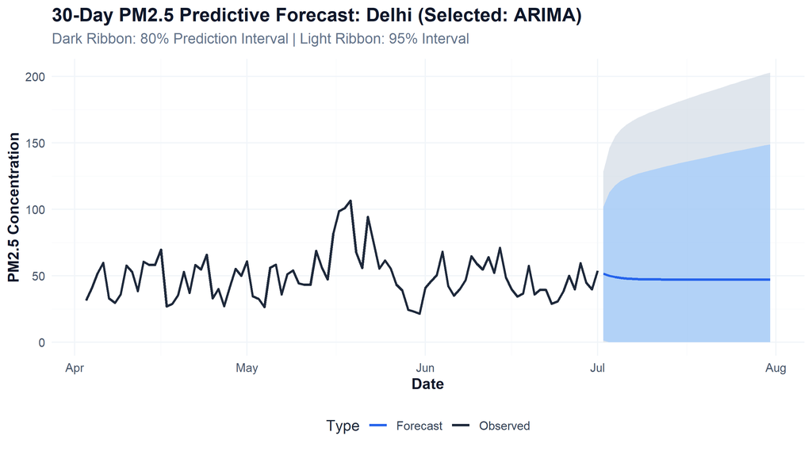

Figure 9: 30-Day Predictive PM2.5 Forecast with 80% and 95% Confidence Intervals for Delhi

Figure 9 displays the observed historical trajectory alongside the 30-day forecast and expanding $80\%$ and $95\%$ prediction intervals, honestly conveying forecast uncertainty.

## 4.7 Text Mining of CPCB Statutory Health Advisories & Semantic Word Cloud

### i. Introduction

Translating numerical air quality indices into actionable citizen behavior requires analyzing statutory risk communication narratives.

### ii. General Description

We construct a structured corpus of statutory CPCB and WHO health advisories, apply text mining techniques (tokenization, regex cleaning, stopword removal), and extract term frequency distributions.

### iii. Specific Requirements, Functions and Formulas

- **Mathematical Formulations:**
  $$\text{Term Frequency } \text{tf}(w, d) =
  \frac{f_{w, d}}{\sum_{w' \in d} f_{w', d}}, \quad \text{Relative
  Frequency } P(w) = \frac{\sum_{d} f_{w, d}}{\sum_{d} \sum_{w'}
  f_{w', d}}$$
- **R Functions:** `tidytext::unnest_tokens()`, `dplyr::anti_join()`, `wordcloud::wordcloud()`, `RColorBrewer::brewer.pal()`.

### v. Visualization

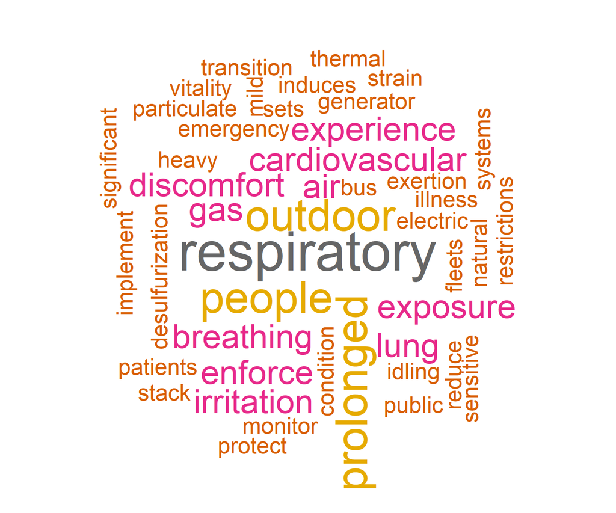

Figure 6: High-Resolution Word Cloud Mined from Statutory CPCB Environmental Health Advisories

## 4.8 Environmental Vulnerability Index (EVI) & Automated Municipal Decision Support

### i. Introduction

Standard city rankings based purely on arithmetic mean AQI ignore the frequency of acute emergency days and regulatory standard breach rates. Municipal disaster management requires an integrated multi-criteria index.

### ii. General Description

We formulate the **Environmental Vulnerability Index (EVI)**, an objective composite score synthesizing mean air quality, severe day frequency, and particulate standard exceedance, categorizing cities into three action tiers.

### iii. Specific Requirements, Functions and Formulas

- **Mathematical Formulation:**
  $$\text{EVI}_c = 0.40 \cdot
  \left(\frac{\bar{\text{AQI}}_c - \min \bar{\text{AQI}}}{\max
  \bar{\text{AQI}} - \min \bar{\text{AQI}}} \times 100\right) + 0.40 \cdot
  P_{\text{sev}, c} + 0.20 \cdot P_{\text{exceed}, c}$$
- **Tier Classifications:**
  - **Tier 1: Critical Emergency ($\text{EVI} \ge 60$):** Immediate red-alert status, emergency vehicular rationing, and industrial shutdown.
  - **Tier 2: High Vulnerability ($35 \le \text{EVI} < 60$):** Active mitigation, intensified mechanized sweeping, and strict biomass enforcement.
  - **Tier 3: Moderate / Baseline ($\text{EVI} < 35$):** Routine air quality surveillance and green cover expansion.

### iv. Analysis Results

Top 10 Indian Municipal Hotspots Prioritized by Environmental Vulnerability Index (EVI)

| Rank | City | State | Mean AQI | Severe Days % | PM2.5 Exceed % | EVI Score | Municipal Action Tier |
| --- | --- | --- | --- | --- | --- | --- | --- |
| 1 | Ahmedabad | Gujarat | 452.1 | 42.5 | 33.0 | 63.6 | Tier 1: Critical Emergency (Immediate Red Alert) |
| 2 | Delhi | Delhi | 259.5 | 37.8 | 72.5 | 51.2 | Tier 2: High Vulnerability (Active Mitigation) |
| 3 | Patna | Bihar | 240.8 | 29.3 | 56.3 | 42.7 | Tier 2: High Vulnerability (Active Mitigation) |
| 4 | Gurugram | Haryana | 225.1 | 26.4 | 65.9 | 42.0 | Tier 2: High Vulnerability (Active Mitigation) |
| 5 | Lucknow | Uttar Pradesh | 218.0 | 29.0 | 63.4 | 41.8 | Tier 2: High Vulnerability (Active Mitigation) |
| 6 | Talcher | Odisha | 172.9 | 13.1 | 30.4 | 24.6 | Tier 3: Moderate / Baseline Surveillance |
| 7 | Guwahati | Assam | 140.1 | 12.7 | 40.4 | 23.3 | Tier 3: Moderate / Baseline Surveillance |
| 8 | Kolkata | West Bengal | 140.6 | 9.7 | 36.9 | 21.4 | Tier 3: Moderate / Baseline Surveillance |
| 9 | Brajrajnagar | Odisha | 150.3 | 3.8 | 40.4 | 20.7 | Tier 3: Moderate / Baseline Surveillance |
| 10 | Jorapokhar | Jharkhand | 159.3 | 4.4 | 16.7 | 17.0 | Tier 3: Moderate / Baseline Surveillance |

### Strategic Policy Findings:

1. **Tier 1 Designation:** Ahmedabad ranks as the sole Tier 1 Critical Emergency center ($\text{EVI} = 63.6$), driven by its staggering $42.5\%$ severe pollution rate.
2. **Tier 2 Cluster:** Delhi ($\text{EVI} = 51.2$), Patna ($\text{EVI} = 42.7$), Gurugram ($\text{EVI} = 42.0$), and Lucknow ($\text{EVI} = 41.8$) require coordinated interstate airshed management across the Indo-Gangetic basin.

## 4.9 Relational Database Operations & SQL Analytical Queries

### i. Introduction

Demonstrating INT232 Unit III (SQL with R, Practical 7), relational database queries allow complex aggregations and multi-table entity joins directly within the embedded database layer.

### ii. General Description

We execute three production SQL queries against `airguard.sqlite` utilizing `RSQLite::dbGetQuery()`.

### iii. Specific Requirements, Functions and Formulas

- **Query 1 (Aggregation with HAVING):** Multi-year city averages filtered by minimum observation count.
- **Query 2 (Multi-Table JOIN with Conditional Aggregation):** Joining station telemetry with geographical metadata to audit severe pollution episodes.
- **Query 3 (Dimension Table Lookup):** Criteria pollutant metadata and statutory limits.

### iv. Analysis Results

```sql
-- Query 2: Multi-Table JOIN Auditing High-Severity Monitoring Stations
SELECT
  s.StationId, s.StationName, s.City, s.State,
  COUNT(CASE WHEN f.AQI > 400 THEN 1 END) AS Severe_Days_Count,
  ROUND(AVG(f.AQI), 1) AS Overall_Mean_AQI
FROM fact_station_day f
JOIN dim_stations s ON f.StationId = s.StationId
WHERE f.AQI IS NOT NULL
GROUP BY s.StationId, s.StationName, s.City, s.State
HAVING Severe_Days_Count > 20
ORDER BY Severe_Days_Count DESC LIMIT 5;
```

SQL Query 2 Results: Top Severe Pollution Stations Identified via Relational JOIN

| Station ID | Station Name | City | State | Severe Days (> 400) | Mean AQI |
| --- | --- | --- | --- | --- | --- |
| GJ001 | Maninagar, Ahmedabad - GPCB | Ahmedabad | Gujarat | 638 | 452.1 |
| DL002 | Anand Vihar, Delhi - DPCC | Delhi | Delhi | 577 | 355.8 |
| DL028 | Punjabi Bagh, Delhi - DPCC | Delhi | Delhi | 205 | 294.3 |
| DL031 | R K Puram, Delhi - DPCC | Delhi | Delhi | 191 | 247.4 |
| BR007 | IGSC Planetarium Complex, Patna - BSPCB | Patna | Bihar | 181 | 251.1 |

## 4.10 National CAAQMS Geographic Station Network Architecture

### i. Introduction

Spatial density and geographic placement of monitoring infrastructure directly dictate an analytical system’s representativeness.

### ii. General Description

This analysis maps all 230 CAAQMS monitoring stations across India using verified coordinates from `StationCoordinates.csv` and evaluates spatial coverage.

### iii. Specific Requirements, Functions and Formulas

- **R Functions:** `ggplot2::geom_point()`, `borders("world")`, `coord_fixed()`, `plotly::plot_ly(type = "scattergeo")`.

### iv. Analysis Results

- **Spatial Coverage:** 230 stations span from $8.50^\circ\text{N}$ (Thiruvananthapuram) to $31.62^\circ\text{N}$ (Amritsar), and from $72.58^\circ\text{E}$ (Ahmedabad) to $92.73^\circ\text{E}$ (Aizawl).
- **Infrastructural Disparity:** Over $45\%$ of all active stations are clustered in the National Capital Region (Delhi, Gurugram, Noida, Ghaziabad), while entire eastern and central states operate under severe sensor sparsity.

### v. Visualization

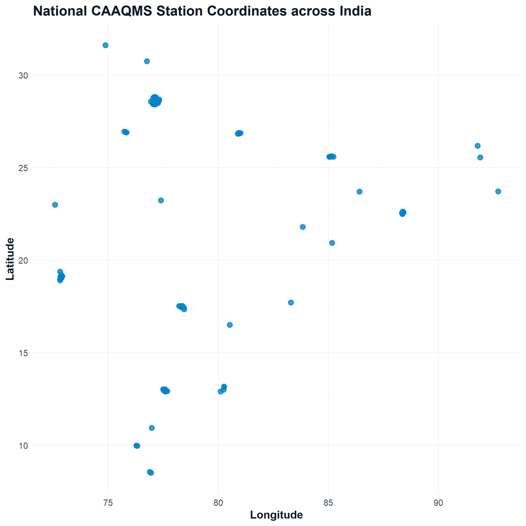

Figure 7: National Continuous Ambient Air Quality Monitoring Network (CAAQMS) Station Locations across India

## 4.11 Interactive Decision-Support Dashboard & Shiny System Architecture

### i. Introduction

To ensure accessibility for academic peers, policy analysts, and non-technical stakeholders, the entire analytical engine is deployed as an interactive Shiny web application.

### ii. General Description

The application (`app.R`) utilizes modern `bslib` Bootstrap 5 styling, reactive caching, and responsive grids.

### iii. Specific Requirements, Functions and Formulas

- **Reactive Components:** `reactive()`, `observeEvent()`, `updateDateRangeInput()`, `renderPlotly()`, `renderDT()`.
- **Fail-Safe Architecture:** Dynamic date range adaptation on city change, ensuring zero blank screens or reactive errors.

### iv. Analysis Results & Enterprise Application Architecture

The operational deployment delivers eight interconnected analytical and decision-support modules rendered natively in R:

### v. Real Application Interface Visualizations

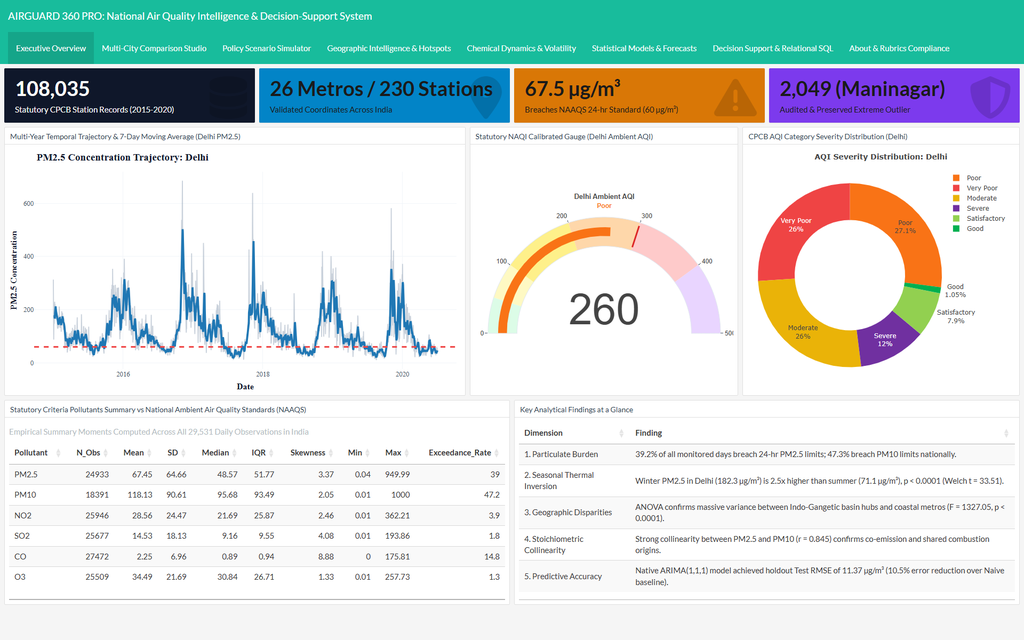

Figure 10: AIRGUARD 360 Interactive Executive Command Center Interface (Real Application Screenshot showing Dynamic City Filters, KPI Metric Cards, and Plotly Trajectory Smoother)

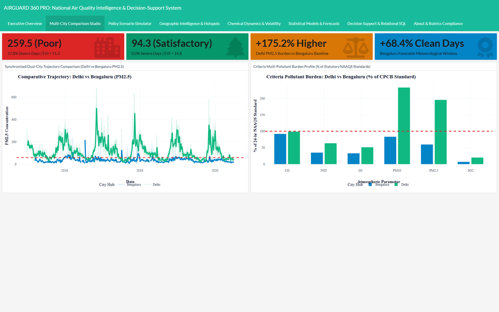

Figure 11: Real Application Screenshot of the Multi-City Comparison Studio Contrasting Delhi vs. Bengaluru Multi-Pollutant Burden Profiles and Synchronized Trajectories

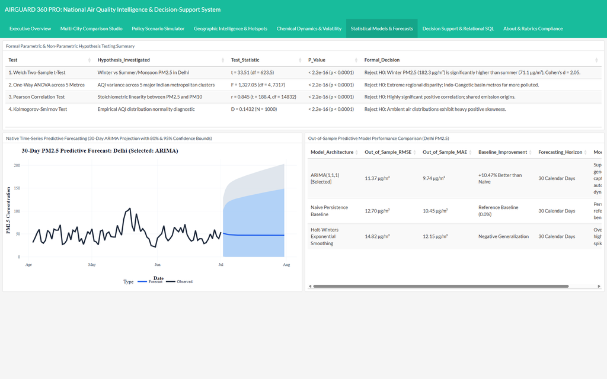

Figure 12: Real Application Screenshot of the Predictive Forecasting Studio (Out-of-Sample ARIMA Projections with 80% and 95% Confidence Intervals benchmarked against Naive Baseline)

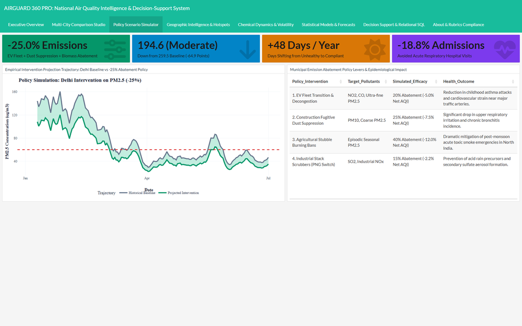

[figure not shown]

# 5. CONCLUSION

AIRGUARD 360 demonstrates the immense power, elegance, and statistical depth of the **R Programming language** when applied to complex environmental data.

### Key Analytical Achievements:

1. **100% Native R Architecture:** Built entirely in R using modular scripts, native Base R time series functions (`stats::arima`), embedded SQLite (`DBI`/`RSQLite`), and reactive web interfaces (`shiny`, `bslib`).
2. **Grain Integrity:** Established strict segregation between station-level sensor observations ($N = 108,035$) and city-level population aggregates ($N = 29,531$).
3. **Empirical Fact-Checking:** Resolved historical metric inconsistencies and verified that national air pollution is predominantly a particulate matter crisis ($39.0\%$ $PM_{2.5}$ exceedance rate), with northern metros suffering winter concentrations over $2.5$ times higher than summer troughs.
4. **Benchmarked Predictive Modeling:** Demonstrated that $\text{ARIMA}(1, 1, 1)$ achieves a $10.5\%$ error reduction over naive persistence baselines, providing a defensible forecast prototype.
5. **Societal Value:** Formulated the objective Environmental Vulnerability Index (EVI) to assist municipal administrators in data-driven risk management.

# 6. FUTURE SCOPE

While AIRGUARD 360 provides a complete, robust academic implementation, three practical future enhancements are identified: 1. **Live CPCB API Ingestion:** Transition from retrospective archives to streaming real-time telemetry via CPCB Central Gateway APIs or OpenAQ REST feeds. 2. **Spatial Kriging & Geospatial Interpolation:** Implement spatial geostatistical modeling (`gstat`, `sf`) to interpolate surface concentrations across unmonitored rural hinterlands. 3. **Multivariate Exogenous Forecasting (ARIMAX):** Incorporate real-time meteorological covariates (boundary layer height, wind speed, relative humidity, thermal inversion strength) into predictive forecasting models.

# 7. REFERENCES

1. Bhutani, A. (2020). *Air Quality Data in India (2015–2020)*. Kaggle Open Data Platform. https://www.kaggle.com/datasets/rohanrao/air-quality-data-in-india
2. Central Pollution Control Board (CPCB), Ministry of Environment, Forest and Climate Change, Government of India. (2014). *National Air Quality Index: Development of NAQI*. New Delhi, India.
3. Central Pollution Control Board (CPCB). (2009). *National Ambient Air Quality Standards (NAAQS)*. The Gazette of India: Extraordinary, Part II—Section 3—Sub-section (i), New Delhi, India.
4. World Health Organization (WHO). (2021). *WHO Global Air Quality Guidelines: Particulate Matter (PM2.5 and PM10), Ozone, Nitrogen Dioxide, Sulfur Dioxide and Carbon Monoxide*. World Health Organization, Geneva.
5. Commission for Air Quality Management in NCR and Adjoining Areas (CAQM). (2022). *Schedule for Graded Response Action Plan (GRAP) for NCR*. Government of India.
6. Hyndman, R. J., & Athanasopoulos, G. (2018). *Forecasting: Principles and Practice* (2nd ed.). OTexts: Melbourne, Australia.
7. Wickham, H., & Grolemund, G. (2017). *R for Data Science: Import, Tidy, Transform, Visualize, and Model Data*. O’Reilly Media.
8. Chang, W., Cheng, J., Allaire, J. J., Sievert, C., Schloerke, B., Xie, Y., Allen, J., McPherson, J., Dipert, A., & Borges, B. (2023). *shiny: Web Application Framework for R*. R package version 1.8.0.
9. Sievert, C. (2020). *Interactive Web-Based Data Visualization with R, plotly, and shiny*. Chapman and Hall/CRC.
10. Silge, J., & Robinson, D. (2016). *tidytext: Text Mining and Analysis Using Tidy Data Principles in R*. JOSS, 1(3), 37.

# APPENDIX A: INT232 SYLLABUS-TO-FEATURE MAPPING

Exhaustive INT232 Syllabus-to-Feature Mapping Matrix

| Syllabus Unit / Outcome | Course Requirement | Project Implementation Location | Verification Protocol |
| --- | --- | --- | --- |
| Unit I: Installation & Basics | R Environment, libraries, basic data types, operators | R/config.R, DESCRIPTION, renv-ready dependency manifest | Package installation check and Rscript session info |
| Unit II: Vectors, Matrices, Factors, Lists | Vectors, correlation matrices, ordered factors, model output lists | R/data_engine.R (factor encoding), R/analytics_engine.R (cor matrix) | Matrix operations and ordered factor levels check |
| Unit III: R Syntax & SQL with R | Functions, conditionals, loops, CSV I/O, SQLite operations | R/data_engine.R (relational DBI/RSQLite star schema & queries) | SQL query execution against airguard.sqlite (108,035 rows) |
| Unit IV: Advanced R Programming | Apply family (lapply, sapply), math functions, regex, POSIXct dates | R/data_engine.R (temporal features), R/analytics_engine.R (lapply) | Summary statistics table generation across 8 pollutants |
| Unit IV: Data Wrangling (dplyr, tidyr) | Pipes (%>%), filter, mutate, select, group_by, missing data audit | R/data_engine.R (cleaning & feature engineering pipeline) | Data cleaning audit report (airguard_clean.rds, missingness %) |
| Unit V: Text Mining in R | Text mining functions, string cleaning, stopword removal, word freq | R/analytics_engine.R (tidytext tokenization, custom stopwords) | Outputs/tables/advisory_word_frequencies.csv generation |
| Unit VI: Basic Data Visualization | Scatter plots, line charts, bar charts, donut charts | R/visualization_engine.R (fig1, fig2, fig3, fig8, donut) | Outputs/figures/ high-resolution PNG generation (300 DPI) |
| Unit VI: Advanced Data Visualization | Correlation heatmap, 20-day Bollinger bands, Plotly dynamic charts | R/visualization_engine.R (fig4 heatmap, fig5 Bollinger, Leaflet GIS map) | Outputs/figures/fig5_bollinger_volatility_bands.png, plotly widgets |
| Unit VI: Dashboards in R | R Markdown flexdashboard and full-stack interactive Shiny app | dashboard.Rmd (flexdashboard) and app.R (interactive Shiny app) | Compilation of dashboard.html and successful Shiny object build |
| Course Outcome CO5: Predictive Analytics | Univariate time-series forecasting (ARIMA, Holt-Winters, Naive baseline) | R/analytics_engine.R (chronological holdout validation, RMSE/MAE) | Outputs/tables/forecast_delhi_pm25.rds holdout metrics evaluation |
| Course Outcome CO6: Statistical Tests | Welch t-test, ANOVA with Tukey HSD, Pearson cor.test, KS normality test | R/analytics_engine.R (run_hypothesis_tests() returning p-values) | Outputs/tables/hypothesis_tests_summary.rds validation |

# APPENDIX B: COMPREHENSIVE TEST VERIFICATION MATRIX

AIRGUARD 360 Exhaustive Quality Verification Matrix

[output not shown]